# AIRLINE PASSENGERS SATISFACTION: CLASSIFICATION

# Linear Discriminant Analysis

Build the *LDA* model

```r
library(MASS)
lda_model <- lda(sat~.,data = dtrain)
lda_model
```

```
Call:
lda(sat ~ ., data = dtrain)

Prior probabilities of groups:
        0         1
0.6313465 0.3686535

Group means:
     gender cust_type      age class_Eco class_Eco_plus  trav_type  distance     wifi time_conv onl_book gate_loc     food onl_board
0 0.4860346 0.7734286 37.64161 0.6209257     0.10204892 0.45969142  955.4562 2.401101  3.248648 2.633328 3.001538 2.906038  2.694796
1 0.5029737 0.9344095 42.96304 0.1507222     0.03483432 0.03763806 1618.0045 3.320816  3.093713 3.187511 2.992608 3.612829  4.181648
   comfort   entert onb_serv leg_room  baggage  checkin infl_serv    clean arr_delay
0 2.996378 2.861835 2.959121 3.010964 3.339832 2.976881  3.319244 2.894528  43.47016
1 4.093968 4.076211 3.918097 3.937298 4.043670 3.713169  4.021495 3.845709  40.61801

Coefficients of linear discriminants:
                         LD1
gender          3.971388e-02
cust_type       1.238212e+00
age             4.720810e-04
class_Eco      -4.624816e-01
class_Eco_plus -5.804161e-01
trav_type      -1.522946e+00
distance        4.165154e-05
wifi            2.751632e-01
time_conv      -7.887685e-02
onl_book       -6.022018e-02
gate_loc       -2.009385e-02
food            2.606311e-03
onl_board       3.736725e-01
comfort         3.471231e-02
entert          8.854973e-02
onb_serv        1.419952e-01
leg_room        1.513261e-01
baggage         9.779672e-02
checkin         1.441539e-01
infl_serv       9.998607e-02
clean           9.724302e-02
arr_delay      -3.522508e-04
```

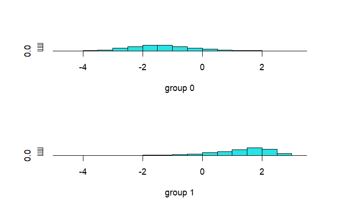

```r
plot(lda_model)
```

Predict the points of the *test set* using the *LDA Model* above implemented:

```r
lda_prediction = predict(lda_model, dtest)
lda_class_prediction = lda_prediction$class
# this prediction yields the class. This will be useful to compute the confusion matrix, because there we will not need the probabilities!
```

Output the confusion matrix

```r
table(lda_class_prediction, dtest$sat)
```

```
lda_class_prediction    0    1
                   0 4644  383
                   1  409 2545
```

```r
mean(lda_class_prediction==dtest$sat)
```

```
[1] 0.9007643
```

ROC for LDA

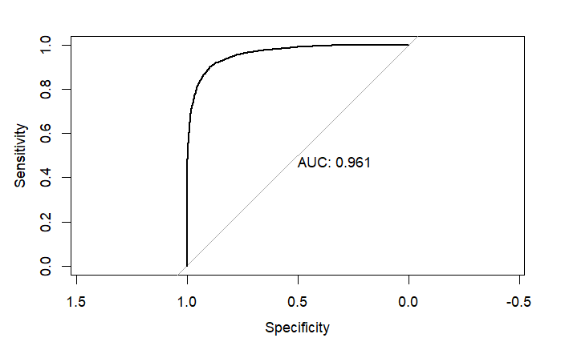

```r
lda_probabilities_prediction = lda_prediction$posterior[, "1"]  # either write 0 or 1!

# given the output produced by predict() we only take the "posterior" column, which gives us the predicted probabilities [0,1] that we need to build the ROC.
# to understand this: if you print "predict(lda_model, dtest)$posterior" we can see that we have two columns, which are complementary. So, we just need one column of them.



test_roc = roc(dtest$sat ~ lda_probabilities_prediction, plot = TRUE, print.auc = TRUE)
```

# Quadratic Discriminant Analysis

```r
qda_model <- qda(sat~.,data = dtrain)
qda_model
```

```
Call:
qda(sat ~ ., data = dtrain)

Prior probabilities of groups:
        0         1
0.6313465 0.3686535

Group means:
     gender cust_type      age class_Eco class_Eco_plus  trav_type  distance     wifi time_conv onl_book gate_loc     food onl_board
0 0.4860346 0.7734286 37.64161 0.6209257     0.10204892 0.45969142  955.4562 2.401101  3.248648 2.633328 3.001538 2.906038  2.694796
1 0.5029737 0.9344095 42.96304 0.1507222     0.03483432 0.03763806 1618.0045 3.320816  3.093713 3.187511 2.992608 3.612829  4.181648
   comfort   entert onb_serv leg_room  baggage  checkin infl_serv    clean arr_delay
0 2.996378 2.861835 2.959121 3.010964 3.339832 2.976881  3.319244 2.894528  43.47016
1 4.093968 4.076211 3.918097 3.937298 4.043670 3.713169  4.021495 3.845709  40.61801
```

Predict the points of the *test set* using the *QDA Model* above implemented:

```r
qda_prediction = predict(qda_model, dtest)
qda_class_prediction = qda_prediction$class
```

Output the confusion matrix

```r
table(qda_class_prediction, dtest$sat)
```

```
qda_class_prediction    0    1
                   0 4512  461
                   1  541 2467
```

```r
mean(qda_class_prediction==dtest$sat)
```

```
[1] 0.8744518
```

Plot the ROC Curve

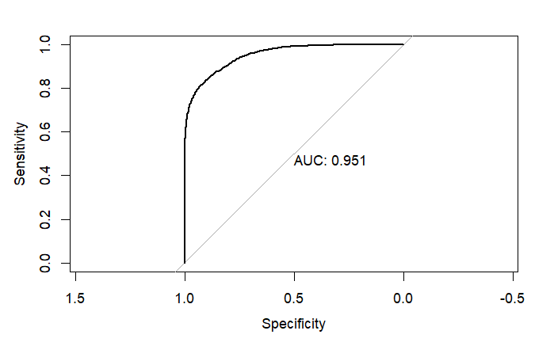

```r
qda_probabilities_prediction <- qda_prediction$posterior[,"1"]

test_roc = roc(dtest$sat ~ qda_probabilities_prediction, plot = TRUE, print.auc = TRUE)
```

# knn

```r
library(class)

# create Data Domain X for the TRAINING set
train_X = dtrain[-23]

# create Data Domain X for the TEST set
test_X= dtest[-23]

# labels of the training set
train_Y = dtrain$sat

# labels of the test set
test_Y = dtest$sat
```

```r
library(ggplot2)

# Define the range of k values to evaluate
k_values <- c(1,3,5,7,9)

# Initialize an empty vector to store the accuracies
accuracies <- c()

# Compute the accuracy for each k value
for (k in k_values) {
  knn_prediction <- knn(train_X, test_X, train_Y, k = k)
  accuracy <- mean(knn_prediction == test_Y)
  accuracies <- c(accuracies, accuracy)
}

# Create a data frame with the k values and accuracies
acc_data <- data.frame(k = k_values, accuracy = accuracies)
```

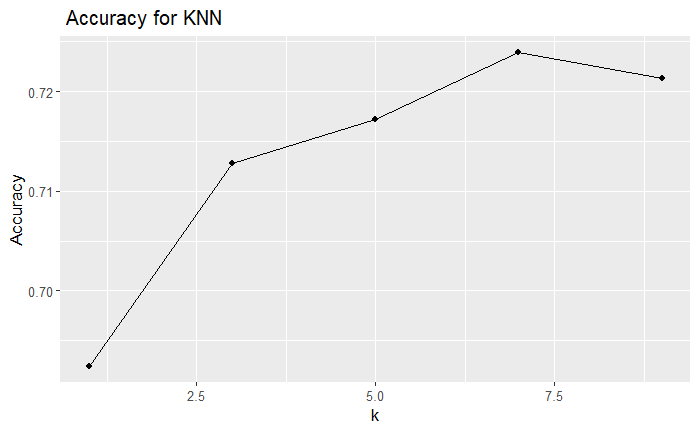

```r
# Plot the elbow plot
ggplot(acc_data, aes(x = k, y = accuracy)) +
  geom_line() +
  geom_point() +
  labs(x = "k", y = "Accuracy") +
  ggtitle(" Accuracy for KNN")
```

Error Rate plot

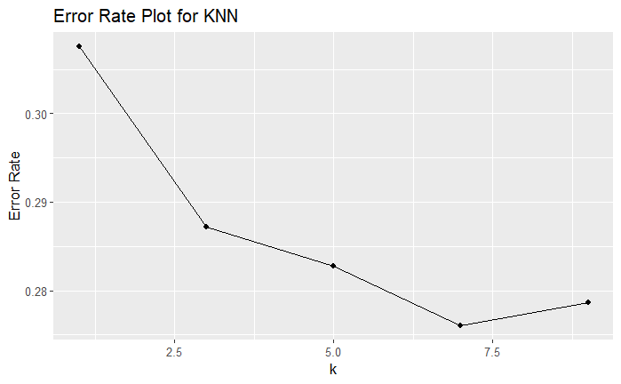

```r
# Initialize an empty vector to store the error rates
error_rates <- c()
k_values <- c(1,3,5,7,9)

for (i in acc_data$accuracy){
error_rate <- 1 - i
error_rates <- c(error_rates, error_rate)
}


# Create a data frame with the k values and error rates
err_data <- data.frame(k = k_values, error_rate = error_rates)

# Plot the error rate plot
ggplot(err_data, aes(x = k, y = error_rate)) +
  geom_line() +
  geom_point() +
  labs(x = "k", y = "Error Rate") +
  ggtitle("Error Rate Plot for KNN")
```

*WE CHOOSE K=7*

in the following chunk, we add prob=TRUE because we need the estimated probabilities to build the ROC later on.

```r
five_nn_prediction <- knn(train_X, test_X, train_Y, k = 7, prob=TRUE)
```

```r
confusion_matrix_knn <- table(test_Y, five_nn_prediction)
confusion_matrix_knn
```

```
      five_nn_prediction
test_Y    0    1
     0 4075  978
     1 1225 1703
```

```r
mean(five_nn_prediction==test_Y)
```

```
[1] 0.7239694
```

# TREE PREDICTOR

```r
library(rpart)
# Convert the response variable to a factor
dtrain$sat <- as.factor(dtrain$sat)
dtest$sat <- as.factor(dtest$sat)

# Train the rpart model
tree_model <- rpart(sat ~ ., data = dtrain)
```

```r
# Make predictions on the test set
predictions <- predict(tree_model, newdata = dtest, type = "class")
```

```r
accuracy <- sum(predictions == dtest$sat) / nrow(dtest) * 100

# Print the accuracy
cat("Accuracy: ", accuracy, "%\n")
```

```
Accuracy:  89.9386 %
```

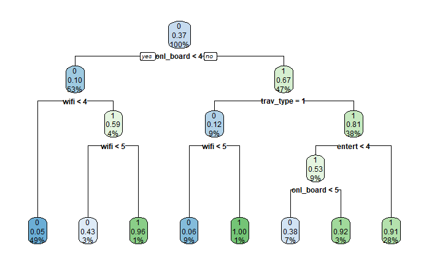

```r
library(rpart.plot)
rpart.plot(tree_model)
```

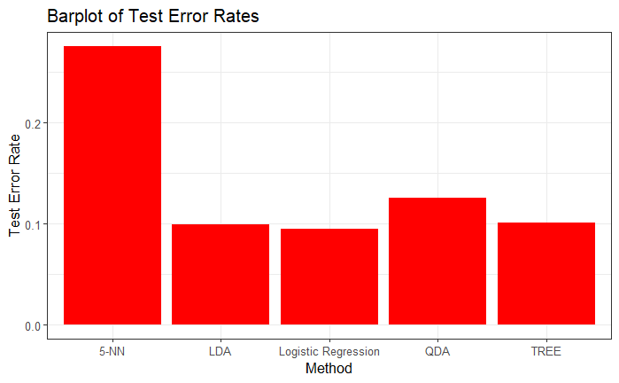

```r
# Calculate test error rates
error_logreg <- mean(logistic_prediction_binary != test_Y)
error_lda <- mean(lda_class_prediction != test_Y)
error_qda <- mean(qda_class_prediction != test_Y)
error_5nn <- mean(five_nn_prediction != test_Y)
error_tree <- mean(predictions != test_Y)
# Create a data frame with method and error rate information
dataaaa <- data.frame(Method = c("Logistic Regression", "LDA", "QDA", "5-NN","TREE"),
                   Error_Rate = c(error_logreg, error_lda, error_qda, error_5nn, error_tree))

# Plot barplot
ggplot(dataaaa, aes(x = Method, y = Error_Rate)) +
  geom_bar(stat = "identity", fill = "Red") +
  ylab("Test Error Rate") +
  ggtitle("Barplot of Test Error Rates") +
  theme_bw()
```